# IL1RN KO Mouse Samples

Adult Hematopoietic Stem Cells

# 1 Load Data

# 2 Raw Counts

```r
GSE126428.rawCounts <- read.delim(file.path(dataPath,"GSE126428_eurofins_rawCount.tab"),sep = "\t",header = T)
GSE126428.rawCounts$GeneName <- gsub("\\(.*","",GSE126428.rawCounts$Description)
GSE126428.rawCounts$Description <- NULL
head(GSE126428.rawCounts)
```

|  | Length | Effective_Length | ENTREZID | X226_KO_LT | X226_KO_ST | X274_KO_LT | X274_KO_ST | X276_KO_LT | X276_KO_ST | CD63_752 | CD63_758 | CD63_769 | CD63_C2 | CD63_C4 | CD63_C5 | E1_LT | E1_ST | E2_LT | E2_ST | E3_LT | E3_ST | X226_KO_MPP | X274_KO_MPP | X276_KO_MPP | E1_MPP | E2_MPP | E3_MPP | GeneName |
| --- | --- | --- | --- | --- | --- | --- | --- | --- | --- | --- | --- | --- | --- | --- | --- | --- | --- | --- | --- | --- | --- | --- | --- | --- | --- | --- | --- | --- |
| gene0 | 472546 | 13987 | 497097 | 0 | 0 | 0 | 0 | 0 | 0 | 0 | 0 | 22 | 0 | 0 | 0 | 0 | 0 | 0 | 0 | 0 | 0 | 0 | 1 | 0 | 0 | 1 | 0 | Xkr4 |
| gene10 | 25655 | 1098 | 108167609 | 0 | 0 | 0 | 0 | 0 | 0 | 0 | 0 | 0 | 0 | 0 | 0 | 0 | 0 | 0 | 0 | 0 | 0 | 0 | 0 | 0 | 0 | 0 | 0 | LOC108167609 |
| gene100 | 168931 | 6646 | 240725 | 0 | 4 | 0 | 0 | 0 | 0 | 510 | 155 | 1491 | 1549 | 583 | 2262 | 0 | 0 | 0 | 0 | 0 | 0 | 0 | 0 | 0 | 0 | 0 | 1 | Sulf1 |
| gene1000 | 128910 | 4032 | 76867 | 396 | 723 | 455 | 463 | 463 | 551 | 500 | 342 | 579 | 217 | 184 | 728 | 402 | 572 | 416 | 588 | 474 | 700 | 450 | 707 | 600 | 396 | 181 | 437 | Rhbdd1 |
| gene10000 | 14561 | 5269 | 27028 | 1878 | 184 | 3465 | 256 | 1768 | 401 | 2636 | 6816 | 6367 | 1771 | 2925 | 4190 | 3893 | 364 | 3778 | 398 | 5328 | 506 | 94 | 81 | 499 | 47 | 64 | 203 | Ermap |
| gene10001 | 5989 | 980 | 69216 | 466 | 571 | 602 | 422 | 351 | 390 | 405 | 1248 | 1357 | 696 | 693 | 705 | 791 | 532 | 627 | 637 | 935 | 685 | 656 | 709 | 539 | 420 | 259 | 830 | Svbp |

```r
GSE126428.rawCounts <- GSE126428.rawCounts %>% dplyr::select(GeneName,ENTREZID,everything()) %>% dplyr::select(-Length,-Effective_Length)

GSE126428.aggCounts <- GSE126428.rawCounts %>% dplyr::select(-ENTREZID)%>% group_by(GeneName) %>% summarise(across(everything(), sum))
```

# 3 LT Analysis

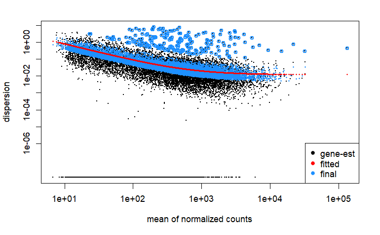

```r
# Select LT experiment
GSE126428.LT.Counts <- GSE126428.aggCounts %>% dplyr::select(GeneName,contains("_LT"))

# Filter genes: at least 1 cpm in at least 3 samples
idx <- which(rowSums(cpm(GSE126428.LT.Counts[,-c(1,2)]) >= 1) >= 3)

GSE126428.LT.FilterCounts <- GSE126428.LT.Counts[idx,]

GSE126428.LT.FilterCounts <- as.data.frame(GSE126428.LT.FilterCounts)
rownames(GSE126428.LT.FilterCounts) <- GSE126428.LT.FilterCounts$GeneName
GSE126428.LT.FilterCounts$GeneName <- NULL

GSE126428.LT.coldata <- data.frame(Sample=colnames(GSE126428.LT.FilterCounts),
                      Condition=factor(c("IL1KO","IL1KO","IL1KO","Ctrl","Ctrl","Ctrl")))

rownames(GSE126428.LT.coldata) <- GSE126428.LT.coldata$Sample

GSE126428.LT.dds <- DESeqDataSetFromMatrix(countData = GSE126428.LT.FilterCounts,
                              colData = GSE126428.LT.coldata,
                              design= ~ Condition)

GSE126428.LT.dds$Condition <- relevel(GSE126428.LT.dds$Condition, ref = "Ctrl")

GSE126428.LT.dds <- DESeq(GSE126428.LT.dds)

plotDispEsts(GSE126428.LT.dds)
```

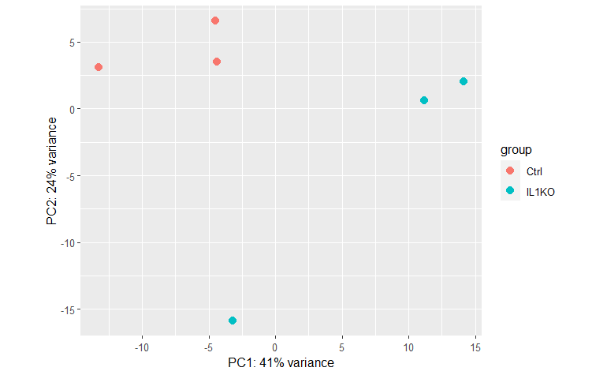

```r
GSE126428.LT.vsd <- vst(GSE126428.LT.dds, blind=FALSE)

plotPCA(GSE126428.LT.vsd,intgroup=c("Condition"))
```

```r
GSE126428.LT.res <- results(GSE126428.LT.dds,alpha = 0.05)
GSE126428.LT.res <- GSE126428.LT.res[order(GSE126428.LT.res$pvalue),]

summary(GSE126428.LT.res)
```

```
out of 14180 with nonzero total read count
adjusted p-value < 0.05
LFC > 0 (up)       : 869, 6.1%
LFC < 0 (down)     : 564, 4%
outliers [1]       : 13, 0.092%
low counts [2]     : 1925, 14%
(mean count < 37)
[1] see 'cooksCutoff' argument of ?results
[2] see 'independentFiltering' argument of ?results
```

```r
GSE126428.LT.res <- as.data.frame(GSE126428.LT.res) %>% mutate(padj2 = p.adjust(pvalue, method = "fdr"))
GSE126428.LT.res$external_gene_name <- rownames(GSE126428.LT.res)

GSE126428.LT.res <- GSE126428.LT.res %>% mutate(score=sqrt(log2FoldChange^2 + (-log10(padj2))^2))

counts_norm <- counts(GSE126428.LT.dds, normalized = TRUE) + 0.5

counts_norm <- counts_norm %>%
  as.data.frame() %>%
  mutate(external_gene_name = rownames(counts_norm)) %>%
  dplyr::select(external_gene_name,everything())

GSE126428.LT.res %>%
  left_join(counts_norm
            , by = c("external_gene_name")) %>%
  write.xlsx(file = file.path(outputPath,"LT_Il1KO_DESeq2_New.xlsx"),overwrite = T)

assign(objects[1], GSE126428.LT.res)
```

File with DESeq2 results + norm counts: ./RNASeq.Analysis/DESeq2.Analysis/LT_Il1KO_DESeq2_New.xlsx

# 4 ST Analysis

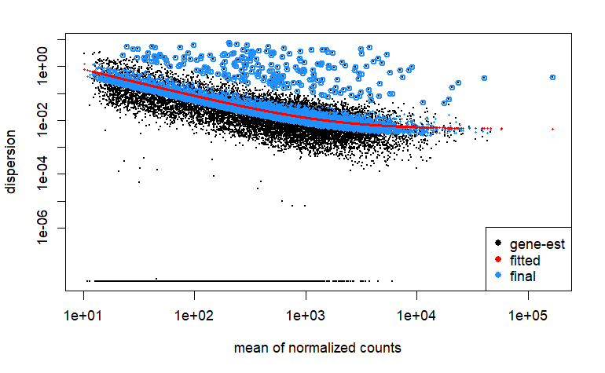

```r
# Select LT experiment
GSE126428.ST.aggCounts <- GSE126428.aggCounts %>% dplyr::select(GeneName,contains("_ST"))

# Filter genes: at least 1 cpm in at least 3 samples
idx <- which(rowSums(cpm(GSE126428.ST.aggCounts[,-c(1,2)]) >= 1) >= 3)
GSE126428.ST.FilterCounts <- GSE126428.ST.aggCounts[idx,]

GSE126428.ST.FilterCounts <- as.data.frame(GSE126428.ST.FilterCounts)
rownames(GSE126428.ST.FilterCounts) <- GSE126428.ST.FilterCounts$GeneName

GSE126428.ST.FilterCounts$GeneName <- NULL

GSE126428.ST.coldata <- data.frame(Sample=colnames(GSE126428.ST.FilterCounts),
                      Condition=factor(c("IL1KO","IL1KO","IL1KO","Ctrl","Ctrl","Ctrl")))

rownames(GSE126428.ST.coldata) <- GSE126428.ST.coldata$Sample

GSE126428.ST.dds <- DESeqDataSetFromMatrix(countData = GSE126428.ST.FilterCounts,
                              colData = GSE126428.ST.coldata,
                              design= ~ Condition)

GSE126428.ST.dds$Condition <- relevel(GSE126428.ST.dds$Condition, ref = "Ctrl")

GSE126428.ST.dds <- DESeq(GSE126428.ST.dds)

plotDispEsts(GSE126428.ST.dds)
```

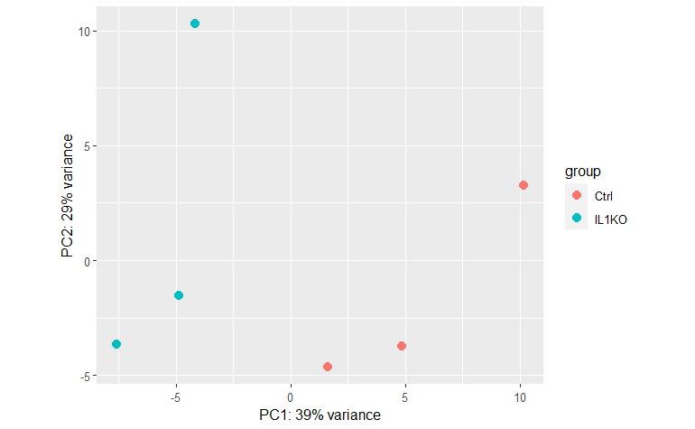

```r
GSE126428.ST.vsd <- vst(GSE126428.ST.dds, blind=FALSE)

plotPCA(GSE126428.ST.vsd,intgroup=c("Condition"))
```

```r
GSE126428.ST.res <- results(GSE126428.ST.dds,alpha = 0.05)
GSE126428.ST.res <- GSE126428.ST.res[order(GSE126428.ST.res$pvalue),]

summary(GSE126428.ST.res)
```

```
out of 14033 with nonzero total read count
adjusted p-value < 0.05
LFC > 0 (up)       : 1524, 11%
LFC < 0 (down)     : 1088, 7.8%
outliers [1]       : 15, 0.11%
low counts [2]     : 1358, 9.7%
(mean count < 37)
[1] see 'cooksCutoff' argument of ?results
[2] see 'independentFiltering' argument of ?results
```

```r
GSE126428.ST.res <- as.data.frame(GSE126428.ST.res) %>% mutate(padj2 = p.adjust(pvalue, method = "fdr"))
GSE126428.ST.res$external_gene_name <- rownames(GSE126428.ST.res)

GSE126428.ST.res <- GSE126428.ST.res %>% mutate(score=sqrt(log2FoldChange^2 + (-log10(padj2))^2))

counts_norm <- counts(GSE126428.ST.dds, normalized = TRUE) + 0.5

counts_norm <- counts_norm %>%
  as.data.frame() %>%
  mutate(external_gene_name = rownames(counts_norm)) %>%
  dplyr::select(external_gene_name,everything())

GSE126428.ST.res %>%
  left_join(counts_norm
            , by = c("external_gene_name")) %>%
  write.xlsx(file = file.path(outputPath,"ST_Il1KO_DESeq2_New.xlsx"),overwrite = T)

assign(objects[2], GSE126428.ST.res)
```

File with DESeq2 results + norm counts: ./RNASeq.Analysis/DESeq2.Analysis/ST_Il1KO_DESeq2_New.xlsx

# 5 MPP Analysis

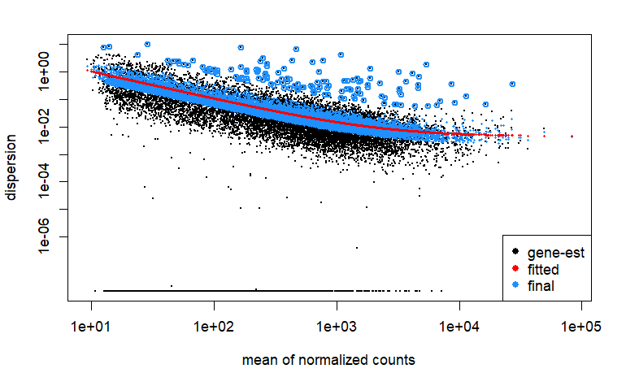

```r
# Select MPP Experiment Samples
GSE126428.MPP.aggCounts <- GSE126428.aggCounts %>% dplyr::select(GeneName,contains("_MPP"))

# Filter genes: at least 1 cpm in at least 3 samples
idx <- which(rowSums(cpm(GSE126428.MPP.aggCounts[,-c(1,2)]) >= 1) >= 3)
GSE126428.MPP.FilterCounts <- GSE126428.MPP.aggCounts[idx,]

GSE126428.MPP.FilterCounts <- as.data.frame(GSE126428.MPP.FilterCounts)
rownames(GSE126428.MPP.FilterCounts) <- GSE126428.MPP.FilterCounts$GeneName

GSE126428.MPP.FilterCounts$GeneName <- NULL

GSE126428.MPP.coldata <- data.frame(Sample=colnames(GSE126428.MPP.FilterCounts),
                      Condition=factor(c("IL1KO","IL1KO","IL1KO","Ctrl","Ctrl","Ctrl")))

rownames(GSE126428.MPP.coldata) <- GSE126428.MPP.coldata$Sample

GSE126428.MPP.dds <- DESeqDataSetFromMatrix(countData = GSE126428.MPP.FilterCounts,
                              colData = GSE126428.MPP.coldata,
                              design= ~ Condition)

GSE126428.MPP.dds$Condition <- relevel(GSE126428.MPP.dds$Condition, ref = "Ctrl")

GSE126428.MPP.dds <- DESeq(GSE126428.MPP.dds)

plotDispEsts(GSE126428.MPP.dds)
```

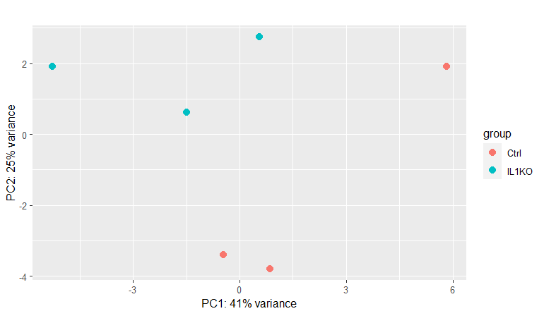

```r
GSE126428.MPP.vsd <- vst(GSE126428.MPP.dds, blind=FALSE)

plotPCA(GSE126428.MPP.vsd,intgroup=c("Condition"))
```

```r
GSE126428.MPP.res <- results(GSE126428.MPP.dds,alpha = 0.05)
GSE126428.MPP.res <- GSE126428.MPP.res[order(GSE126428.MPP.res$pvalue),]

summary(GSE126428.MPP.res)
```

```
out of 13968 with nonzero total read count
adjusted p-value < 0.05
LFC > 0 (up)       : 140, 1%
LFC < 0 (down)     : 41, 0.29%
outliers [1]       : 11, 0.079%
low counts [2]     : 542, 3.9%
(mean count < 20)
[1] see 'cooksCutoff' argument of ?results
[2] see 'independentFiltering' argument of ?results
```

```r
GSE126428.MPP.res <- as.data.frame(GSE126428.MPP.res) %>% mutate(padj2 = p.adjust(pvalue, method = "fdr"))
GSE126428.MPP.res$external_gene_name <- rownames(GSE126428.MPP.res)

GSE126428.MPP.res <- GSE126428.MPP.res %>% mutate(score=sqrt(log2FoldChange^2 + (-log10(padj2))^2))

counts_norm <- counts(GSE126428.MPP.dds, normalized = TRUE) + 0.5

counts_norm <- counts_norm %>%
  as.data.frame() %>%
  mutate(external_gene_name = rownames(counts_norm)) %>%
  dplyr::select(external_gene_name,everything())

GSE126428.MPP.res %>%
  left_join(counts_norm
            , by = c("external_gene_name")) %>%
  write.xlsx(file = file.path(outputPath,"MPP_Il1KO_DESeq2_New.xlsx"), overwrite = T)

assign(objects[3], GSE126428.MPP.res)
```

File with DESeq2 results + norm counts: ./RNASeq.Analysis/DESeq2.Analysis/MPP_Il1KO_DESeq2_New.xlsx

# 6 Import NfkB Target Genes

```r
all <- rbind(LT_Il1rnKO,ST_Il1rnKO,MPP_Il1rnKO)
```

```r
nfkbList1 <- read_delim(file.path(dataPath,"NfkbTargets1.txt"),delim = "\t",col_names = T) %>%
  mutate(Source="Gilmore", MouseGeneName=NA) %>%
  dplyr::select(MouseGeneName,HumanGeneName,Acc,Category,Evidence,Source) %>%
  filter(!is.na(Acc))
nfkbList1 <- nfkbList1[match(unique(sort(nfkbList1$Acc)),nfkbList1$Acc),]

nfkbList2 <- read_delim(file.path(dataPath,"NfkbTargets2.txt"),delim = "\t",col_names = T) %>%
  mutate(Category = "Gosselin", Source="Gosselin", MouseGeneName=NA) %>%
  rename("HumanGeneName"=Name,"Acc"=RefSeq_Human) %>%
  dplyr::select(MouseGeneName,HumanGeneName,Acc,Category,Evidence,Source) %>%
  filter(!is.na(Acc))
nfkbList2 <- nfkbList2[match(unique(sort(nfkbList2$Acc)),nfkbList2$Acc),]

nfkbList3 <- read_delim(file.path(dataPath,"Supplementary Table S4.txt"),delim = "\t",col_names = T) %>%
  distinct(TF,Target) %>%
  mutate(Evidence="P",Source="Arranz",Acc=NA,HumanGeneName=NA) %>%
  rename("MouseGeneName"=Target,"Category"=TF) %>%
  dplyr::select(MouseGeneName,HumanGeneName,Acc,Category,Evidence,Source)
```

```r
# Map human to mouse genes
commonName <- "mouse"
wspecies <- "Homo_sapiens"
sp <- "hsapiens"
# spGeneNames <- "mgi_symbol"

genebuildVersion <- "91"
genomeVersion <- "GRCm38"
archive <- "dec2017.archive"
```

```r
mart <- useMart(host=paste(archive,"ensembl.org",sep = "."), path="/biomart/martservice"
                , biomart = "ENSEMBL_MART_ENSEMBL"
                , port=80,  verbose = T)
```

| V1 |
| --- |
| 0.7 |

```
BioMartServer running BioMart version: 0.7
Mart virtual schema: default
Mart host: http://dec2017.archive.ensembl.org:80/biomart/martservice
```

```r
mart <- useDataset(paste(sp,"gene","ensembl",sep="_"),mart)

attrList <- listAttributes(mart)

# Source Gilmore
genesMetadataNames <- getBM(attributes = c(
                                      "external_gene_name"
                                      ,"ensembl_gene_id"
                                      ,"refseq_mrna"
)
,uniqueRows=T, mart = mart, filters = "refseq_mrna", values =  nfkbList1$Acc
)
genesMetadata <- getBM(attributes = c("ensembl_gene_id"
                                      ,"mmusculus_homolog_associated_gene_name"
                                      ,"mmusculus_homolog_orthology_type"
                                      ,"mmusculus_homolog_perc_id"
                                      ,"mmusculus_homolog_perc_id_r1"
                                      ,"mmusculus_homolog_orthology_confidence")
                       ,uniqueRows=T, mart = mart, filters = "refseq_mrna", values =  nfkbList1$Acc)
genesMetadata <- genesMetadata %>% filter(mmusculus_homolog_orthology_type %in% c("ortholog_one2one"))
genesMetadata <- genesMetadata %>%
  filter(mmusculus_homolog_orthology_type %in% c("ortholog_one2one")) %>%
  left_join(genesMetadataNames,by = "ensembl_gene_id")

nfkbList1 <- nfkbList1 %>% left_join(genesMetadata,by = c("Acc"="refseq_mrna"))
nfkbList1 <- nfkbList1 %>% mutate(MouseGeneName = nfkbList1$mmusculus_homolog_associated_gene_name)
nfkbList1 <- nfkbList1 %>% filter(!is.na(MouseGeneName))

# Source Gosselin
genesMetadataNames2 <- getBM(attributes = c(
                                      "external_gene_name"
                                      ,"ensembl_gene_id"
                                      ,"refseq_mrna"
)
,uniqueRows=T, mart = mart, filters = "refseq_mrna", values =  nfkbList2$Acc
)
genesMetadata2 <- getBM(attributes = c(
                                      "ensembl_gene_id"
                                      ,"mmusculus_homolog_associated_gene_name"
                                      ,"mmusculus_homolog_orthology_type"
                                      ,"mmusculus_homolog_perc_id"
                                      ,"mmusculus_homolog_perc_id_r1"
                                      ,"mmusculus_homolog_orthology_confidence")
                       ,uniqueRows=T, mart = mart, filters = "refseq_mrna", values =  nfkbList2$Acc)
genesMetadata2 <- genesMetadata2 %>%
  filter(mmusculus_homolog_orthology_type %in% c("ortholog_one2one")) %>%
  left_join(genesMetadataNames2,by = "ensembl_gene_id")

nfkbList2 <- nfkbList2 %>% left_join(genesMetadata2,by = c("Acc"="refseq_mrna"))
nfkbList2 <- nfkbList2 %>% mutate(MouseGeneName = nfkbList2$mmusculus_homolog_associated_gene_name)
nfkbList2 <- nfkbList2 %>% filter(!is.na(MouseGeneName))
```

## 6.1 Targets From Gilmore dataset

Targets 338.

With Mouse OneToOne Ortholog 338.

Found in our dataset: 205.

Significant in our dataset: 59.

## 6.2 Targets From Gosselin dataset

Targets 133.

With Mouse OneToOne Ortholog 133.

Found in our dataset: 78.

Significant in our dataset: 20.

## 6.3 Targets from Arranz

Total genes in Arranz: 1830.

Found in our dataset: 1798.

Significant in our dataset: 492.

## 6.4 All Target Genes

```r
nfkbGeneNames <- unique(sort(c(nfkbList1$MouseGeneName,nfkbList2$MouseGeneName,nfkbList3$MouseGeneName)))
```

Total genes: 2132.

Found in our dataset: 1962.

Significant in our dataset: 536.

```r
allTargets <- data.frame(MouseGeneName=nfkbGeneNames)

allTargets <- allTargets %>% left_join(nfkbList1 %>% filter(!is.na(MouseGeneName)) %>% dplyr::select(MouseGeneName,Category), by = c("MouseGeneName"="MouseGeneName")) %>%
  rename("Gilmore"=Category)

allTargets <- allTargets %>% left_join(nfkbList2 %>% filter(!is.na(MouseGeneName)) %>% dplyr::select(MouseGeneName,Category), by = c("MouseGeneName"="MouseGeneName")) %>%
  rename("Gosselin"=Category)

for (arcat in c("NFKB","NFKB1","NFKB2","REL","RELA")) {
  allTargets <- allTargets %>% left_join(nfkbList3 %>% dplyr::select(MouseGeneName,Category) %>% distinct(MouseGeneName,Category) %>% filter(Category == arcat), by = c("MouseGeneName"="MouseGeneName")) %>%
    rename(!!paste0("Arranz_",arcat):=Category)
}

allTargets <- allTargets %>%
  mutate(LT_Il1rnKO=ifelse(!MouseGeneName %in% LT_Il1rnKO$external_gene_name,NA,ifelse(MouseGeneName %in% LT_Il1rnKO[LT_Il1rnKO$padj2 < 0.05,"external_gene_name"],T,F))) %>%
  mutate(ST_Il1rnKO=ifelse(!MouseGeneName %in% ST_Il1rnKO$external_gene_name,NA,ifelse(MouseGeneName %in% ST_Il1rnKO[ST_Il1rnKO$padj2 < 0.05,"external_gene_name"],T,F))) %>%
  mutate(MPP_Il1rnKO=ifelse(!MouseGeneName %in% MPP_Il1rnKO$external_gene_name,NA,ifelse(MouseGeneName %in% MPP_Il1rnKO[MPP_Il1rnKO$padj2 < 0.05,"external_gene_name"],T,F)))

allTargets %>% write.xlsx(file = file.path(outputPath,"NFKB.TargetsLists.xlsx"),overwrite = T)
```

# 7 Annotate DE Tables with Nfkb targets

```r
LT_Il1rnKO$isTarget <- F

LT_Il1rnKO <- LT_Il1rnKO %>% left_join(nfkbList1 %>% dplyr::select(MouseGeneName,Category), by = c("external_gene_name"="MouseGeneName")) %>%
  mutate(isTarget=ifelse(!is.na(Category),T,isTarget)) %>%
  rename("Gilmore"=Category)

LT_Il1rnKO <- LT_Il1rnKO %>% left_join(nfkbList2 %>% dplyr::select(MouseGeneName,Category), by = c("external_gene_name"="MouseGeneName")) %>%
  mutate(isTarget=ifelse(!is.na(Category),T,isTarget)) %>%
  rename("Gosselin"=Category)

for (arcat in c("NFKB","NFKB1","NFKB2","REL","RELA")) {
  LT_Il1rnKO <- LT_Il1rnKO %>% left_join(nfkbList3 %>%
                                           dplyr::select(MouseGeneName,Category) %>%
                                           distinct(MouseGeneName,Category) %>%
                                           filter(Category == arcat), by = c("external_gene_name"="MouseGeneName")) %>%
    mutate(isTarget=ifelse(!is.na(Category),T,isTarget)) %>%
    rename(!!paste0("Arranz_",arcat):=Category)
}

LT_Il1rnKO <- LT_Il1rnKO %>% mutate(score=sqrt(log2FoldChange^2 + (-log10(padj2))^2)) %>% arrange(desc(score))
LT_Il1rnKO %>% write.xlsx(file = file.path(outputPath,"LT_Il1rnKO.nfkbAnnot.xlsx"),overwrite = T)
```

```r
ST_Il1rnKO$isTarget <- F
ST_Il1rnKO <- ST_Il1rnKO %>% left_join(nfkbList1 %>% dplyr::select(MouseGeneName,Category), by = c("external_gene_name"="MouseGeneName")) %>%
  mutate(isTarget=ifelse(!is.na(Category),T,isTarget)) %>%
  rename("Gilmore"=Category)

ST_Il1rnKO <- ST_Il1rnKO %>% left_join(nfkbList2 %>% dplyr::select(MouseGeneName,Category), by = c("external_gene_name"="MouseGeneName")) %>%
  mutate(isTarget=ifelse(!is.na(Category),T,isTarget)) %>%
  rename("Gosselin"=Category)

for (arcat in c("NFKB","NFKB1","NFKB2","REL","RELA")) {
  ST_Il1rnKO <- ST_Il1rnKO %>% left_join(nfkbList3 %>%
                                           dplyr::select(MouseGeneName,Category) %>%
                                           distinct(MouseGeneName,Category) %>%
                                           filter(Category == arcat), by = c("external_gene_name"="MouseGeneName")) %>%
    mutate(isTarget=ifelse(!is.na(Category),T,isTarget)) %>%
    rename(!!paste0("Arranz_",arcat):=Category)
}
ST_Il1rnKO <- ST_Il1rnKO %>% mutate(score=sqrt(log2FoldChange^2 + (-log10(padj2))^2)) %>% arrange(desc(score))
ST_Il1rnKO %>% write.xlsx(file = file.path(outputPath,"ST_Il1rnKO.nfkbAnnot.xlsx"),overwrite = T)
```

```r
MPP_Il1rnKO$isTarget <- F
MPP_Il1rnKO <- MPP_Il1rnKO %>% left_join(nfkbList1 %>% dplyr::select(MouseGeneName,Category), by = c("external_gene_name"="MouseGeneName")) %>%
  mutate(isTarget=ifelse(!is.na(Category),T,isTarget)) %>%
  rename("Gilmore"=Category)

MPP_Il1rnKO <- MPP_Il1rnKO %>% left_join(nfkbList2 %>% dplyr::select(MouseGeneName,Category), by = c("external_gene_name"="MouseGeneName")) %>%
  mutate(isTarget=ifelse(!is.na(Category),T,isTarget)) %>%
  rename("Gosselin"=Category)

for (arcat in c("NFKB","NFKB1","NFKB2","REL","RELA")) {
  MPP_Il1rnKO <- MPP_Il1rnKO %>% left_join(nfkbList3 %>%
                                             dplyr::select(MouseGeneName,Category) %>%
                                             distinct(MouseGeneName,Category) %>%
                                             filter(Category == arcat), by = c("external_gene_name"="MouseGeneName")) %>%
    mutate(isTarget=ifelse(!is.na(Category),T,isTarget)) %>%
    rename(!!paste0("Arranz_",arcat):=Category)
}
MPP_Il1rnKO <- MPP_Il1rnKO %>% mutate(score=sqrt(log2FoldChange^2 + (-log10(padj2))^2)) %>% arrange(desc(score))
MPP_Il1rnKO %>% write.xlsx(file = file.path(outputPath,"MPP_Il1rnKO.nfkbAnnot.xlsx"),overwrite = T)
```

# 8 Overlaps Between Contrasts

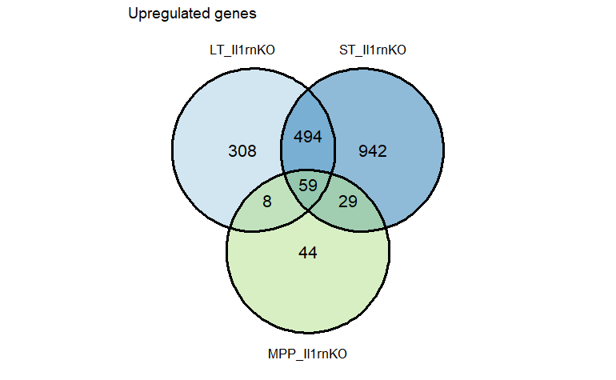

```r
# Overlap between contrasts of significantly upregulated genes
deList <- list(
  LT_Il1rnKO = LT_Il1rnKO %>% filter(padj < 0.05 & log2FoldChange > 0) %>% .$external_gene_name,
  ST_Il1rnKO = ST_Il1rnKO %>% filter(padj < 0.05 & log2FoldChange > 0) %>% .$external_gene_name,
  MPP_Il1rnKO = MPP_Il1rnKO %>% filter(padj < 0.05 & log2FoldChange > 0) %>% .$external_gene_name
)

ggvenn(deList, names(deList),
       show_percentage = F,
       fill_color = color.list,
       set_name_size = 4,
       text_size = 5) +
  ggtitle("Upregulated genes")
```

```r
NA
NA
```

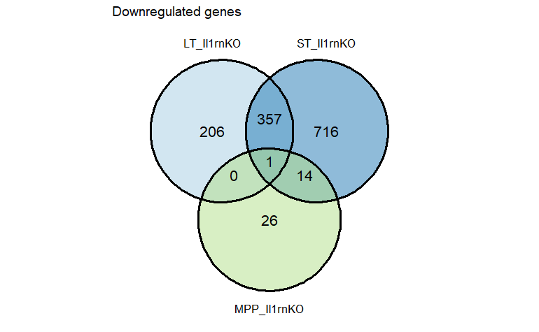

```r
# Overlap between contrasts of significantly downregulated genes
deList <- list(
  LT_Il1rnKO = LT_Il1rnKO %>% filter(padj < 0.05 & log2FoldChange < 0) %>% .$external_gene_name,
  ST_Il1rnKO = ST_Il1rnKO %>% filter(padj < 0.05 & log2FoldChange < 0) %>% .$external_gene_name,
  MPP_Il1rnKO = MPP_Il1rnKO %>% filter(padj < 0.05 & log2FoldChange < 0) %>% .$external_gene_name
)

ggvenn(deList, names(deList),
       show_percentage = F,
       fill_color = color.list,
       set_name_size = 4,
       text_size = 5) +
  ggtitle("Downregulated genes")
```

# 9 Vulcano Plots

```r
toLabel = list()
for (i in 1:3) {
  toLabel[[objects[i]]] <- read.xlsx(file.path(dataPath,"toLabel",paste0(objects[i],".nfkbAnnot.xlsx")))
  toLabel[[objects[i]]] <- toLabel[[objects[i]]] %>% filter(toLabel == 1) %>% dplyr::select(external_gene_name)
}
lapply(toLabel, dim)
```

```
$LT_Il1rnKO
[1] 29  1

$ST_Il1rnKO
[1] 33  1

$MPP_Il1rnKO
[1] 21  1
```

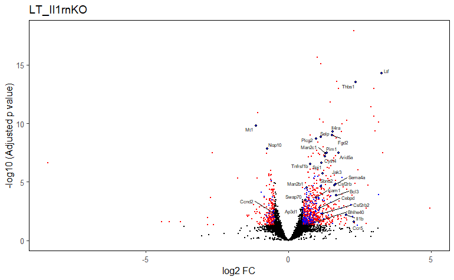

```r
pCutoff=0.05
FCcutoff=0.5
for(i in 1:3) {

  temp <- get(objects[i])

  temp <- temp %>% mutate(toLabel = external_gene_name %in% toLabel[[objects[i]]]$external_gene_name )

  # Get list of Ribosomic related genes
  riboMtOthers = temp[grep("^Rpl|^Rps|^mt-|^Ig[a-z]v", temp$external_gene_name),"external_gene_name"]

  # Remove genes with low expression & pvalue over 0.05 | p_adjusted_value over 1
  temp <- temp %>% filter(!is.na(padj)) %>%
    filter(!(baseMean < 500 & pvalue > 0.05)) %>%
    filter(padj < 1)

  # Order by distance to 0 in the vulcano plot
  temp <- temp %>% arrange(-score)

  # Remove predicted genes (Gm)
  temp <- temp %>% filter(!grepl("Gm[0-9]+", external_gene_name))

  # Label selected Nfkb genes except ribo genes
  temp <- temp %>% mutate(anno = ifelse(toLabel == T,external_gene_name,"")) %>%
    mutate(anno = ifelse(external_gene_name %in% riboMtOthers,"",anno))

  # Mark as red all genes below 0.05 and with LFC over 0.5
  temp <- temp %>% mutate(fillme = "black", size = 0.1) %>%
    mutate(fillme = ifelse(padj < pCutoff & abs(log2FoldChange) > FCcutoff,"red",fillme))

  # Mark as blue all significant Nkfb targets and increase size and border color of labeled genes
  temp <- temp %>% mutate(fillme = ifelse(isTarget & fillme == "red","blue",fillme)) %>%
    mutate(colorme = ifelse(anno != "","black",fillme)) %>%
    mutate(sizeme = ifelse(anno != "",1,size))

  temp <- temp %>% mutate(log2FoldChange = round(log2FoldChange, 2)) %>%
    mutate(padj = signif(temp$padj, 3))

  temp <- temp %>% arrange(anno,isTarget,desc(score))

  p <- as.data.frame(temp) %>% ggplot(aes(x = log2FoldChange, y = -log10(padj))
                       ) +
    geom_point(shape = 21, fill = temp$fillme, color = temp$colorme, size = temp$sizeme) +
    geom_text_repel(size = 2, label = temp$anno,
                    point.padding = unit(1e-10, "lines"),
                    # segment.color = 'transparent',
                    box.padding = 0.1,
                    max.overlaps = 500,
                    seed = 42
    ) +
    ggtitle(objects[i]) +
    theme(panel.background = element_blank(),
          axis.line = element_line(),
          panel.border = element_rect(fill = "transparent")
    ) +
    ylab("-log10 (Adjusted p value)") + xlab("log2 FC")

  assign(paste("p", objects[i], sep = "."), p)

}

p.LT_Il1rnKO
```

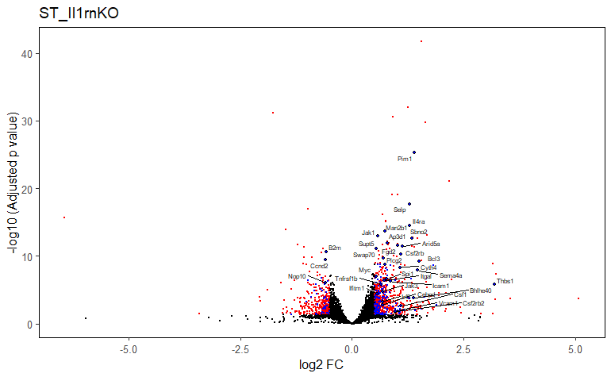

```r
p.ST_Il1rnKO
```

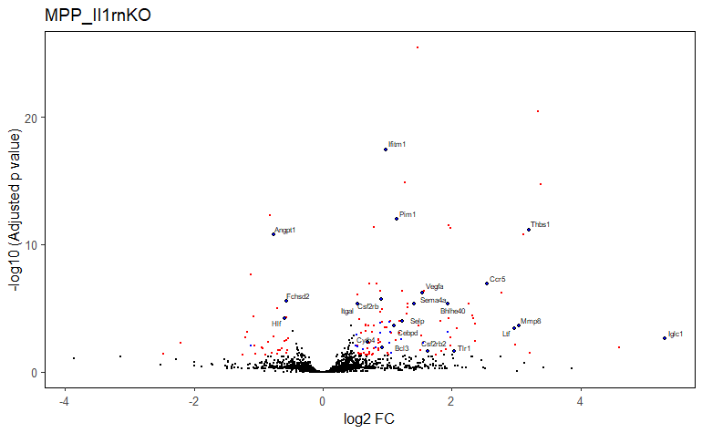

```r
p.MPP_Il1rnKO
```

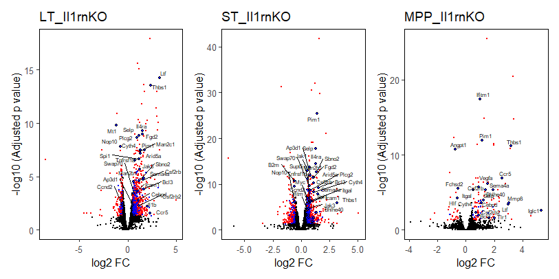

```r
p.LT_Il1rnKO + p.ST_Il1rnKO + p.MPP_Il1rnKO
```

# 10 CD63 Analysis

```r
objects <- c(objects,"CD63_Il1rnKO")
```

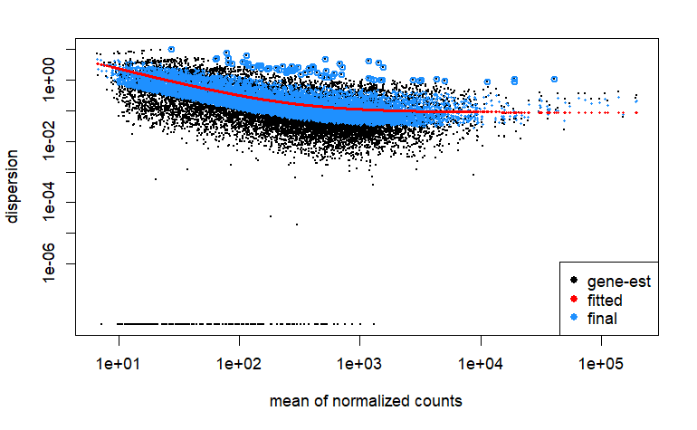

```r
# Select MPP Experiment Samples
GSE126428.CD63.aggCounts <- GSE126428.aggCounts %>% dplyr::select(GeneName,contains("CD63"))

# Filter genes: at least 1 cpm in at least 3 samples
idx <- which(rowSums(cpm(GSE126428.CD63.aggCounts[,-c(1,2)]) >= 1) >= 3)
GSE126428.CD63.FilterCounts <- GSE126428.CD63.aggCounts[idx,]

GSE126428.CD63.FilterCounts <- as.data.frame(GSE126428.CD63.FilterCounts)
rownames(GSE126428.CD63.FilterCounts) <- GSE126428.CD63.FilterCounts$GeneName

GSE126428.CD63.FilterCounts$GeneName <- NULL

GSE126428.CD63.coldata <- data.frame(Sample=colnames(GSE126428.CD63.FilterCounts),
                      Condition=factor(c("IL1KO","IL1KO","IL1KO","Ctrl","Ctrl","Ctrl")))

rownames(GSE126428.CD63.coldata) <- GSE126428.CD63.coldata$Sample

GSE126428.CD63.dds <- DESeqDataSetFromMatrix(countData = GSE126428.CD63.FilterCounts,
                              colData = GSE126428.CD63.coldata,
                              design= ~ Condition)

GSE126428.CD63.dds$Condition <- relevel(GSE126428.CD63.dds$Condition, ref = "Ctrl")

GSE126428.CD63.dds <- DESeq(GSE126428.CD63.dds)

plotDispEsts(GSE126428.CD63.dds)
```

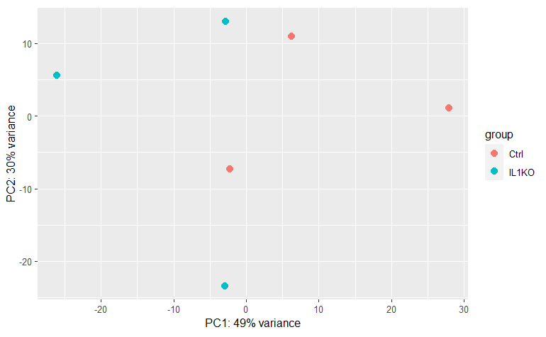

```r
GSE126428.CD63.vsd <- vst(GSE126428.CD63.dds, blind=FALSE)

plotPCA(GSE126428.CD63.vsd,intgroup=c("Condition"))
```

```r
GSE126428.CD63.res <- results(GSE126428.CD63.dds,alpha = 0.05)
GSE126428.CD63.res <- GSE126428.CD63.res[order(GSE126428.CD63.res$pvalue),]

summary(GSE126428.CD63.res)
```

```
out of 14672 with nonzero total read count
adjusted p-value < 0.05
LFC > 0 (up)       : 14, 0.095%
LFC < 0 (down)     : 101, 0.69%
outliers [1]       : 22, 0.15%
low counts [2]     : 569, 3.9%
(mean count < 17)
[1] see 'cooksCutoff' argument of ?results
[2] see 'independentFiltering' argument of ?results
```

```r
GSE126428.CD63.res <- as.data.frame(GSE126428.CD63.res) %>% mutate(padj2 = p.adjust(pvalue, method = "fdr"))
GSE126428.CD63.res$external_gene_name <- rownames(GSE126428.CD63.res)

GSE126428.CD63.res <- GSE126428.CD63.res %>% mutate(score=sqrt(log2FoldChange^2 + (-log10(padj2))^2))

counts_norm <- counts(GSE126428.CD63.dds, normalized = TRUE) + 0.5

counts_norm <- counts_norm %>%
  as.data.frame() %>%
  mutate(external_gene_name = rownames(counts_norm)) %>%
  dplyr::select(external_gene_name,everything())

GSE126428.CD63.res %>%
  left_join(counts_norm
            , by = c("external_gene_name")) %>%
  write.xlsx(file = file.path(outputPath,"CD63_Il1KO_DESeq2_New.xlsx"), overwrite = T)

assign(objects[4], GSE126428.CD63.res)
```

File with DESeq2 results + norm counts: CD63_Il1KO_DESeq2_New.xlsx

# 11 Vulcano on CD63

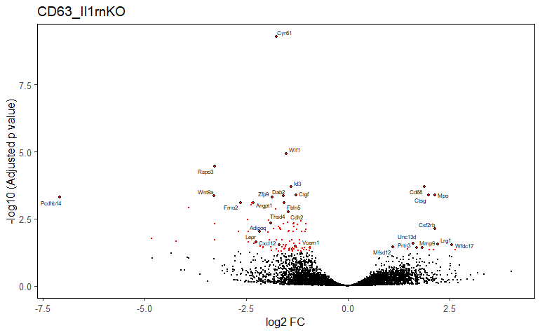

```r
# CD63 Experiment Vulcano Plot
toLabel <- c("Wif1","Id3","Dab2","Zfp9","Ctgf","Angpt1","Fbln5","Cdh2","Lepr","Adipoq","Thsd4","Cxcl12","Vcam1","Cd68","Ctsg","Mpo","Podxl","Csf2rb","Unc13d","Lrg1","Wfdc17","Mfsd12","Prtn3")

pCutoff=0.05
FCcutoff=0.1

temp <- get(objects[4])

# Get list of Ribosomic related genes
riboMtOthers = temp[grep("^Rpl|^Rps|^mt-|^Ig[a-z]v", temp$external_gene_name),"external_gene_name"]

# Remove genes with low expression & pvalue over 0.05 | p_adjusted_value over 1
temp <- temp %>% filter(!is.na(padj)) %>%
  filter(padj < 1)

# Order by distance to 0 in the vulcano plot
temp <- temp %>% mutate(score=sqrt(log2FoldChange^2 + (-log10(padj2))^2)) %>% arrange(desc(score)) %>% arrange(padj)

# Remove predicted genes (Gm)
temp <- temp %>% filter(!grepl("Gm[0-9]+", external_gene_name))

# Label top 10 up and top 10 down genes plus selected ones
dummy <- temp %>% mutate(up = log2FoldChange > 0) %>% group_split(up)
toLabel <- unique(sort(c(toLabel,unlist(lapply(dummy,function (x) {return(head(x %>% filter(padj < 0.05) %>% .$external_gene_name,10))})))))

# Label selected genes except ribo genes
temp <- temp %>% mutate(anno = ifelse(external_gene_name %in% toLabel,external_gene_name,"")) %>%
  mutate(anno = ifelse(external_gene_name %in% riboMtOthers,"",anno))

temp <- temp %>% mutate(fill = "black", size = 0.1) %>%
  mutate(fill = ifelse(padj < pCutoff & abs(log2FoldChange) > FCcutoff,"red",fill)) %>%
  mutate(color = ifelse(anno != "","black",fill)) %>%
  mutate(size = ifelse(anno != "",1,size)) %>%
  mutate(log2FoldChange = round(log2FoldChange, 2)) %>%
  mutate(padj = signif(temp$padj, 3)) %>%
  arrange(desc(anno),desc(score))

p <- temp %>%
  ggplot(aes(x = log2FoldChange, y = -log10(padj))) +
  geom_point(shape = 21, fill = temp$fill, color = temp$color, size = temp$size) +
  geom_text_repel(size = 2, label = temp$anno,
                  point.padding = unit(1e-10, "lines"),
                  segment.color = 'black',
                  box.padding = 0.1,
                  max.overlaps = 1000,
                  seed = 42
  ) +
  ggtitle(objects[4]) +
  theme(panel.background = element_blank(),
        axis.line = element_line(),
        panel.border = element_rect(fill = "transparent")
  ) +
  ylab("-log10 (Adjusted p value)") + xlab("log2 FC")

assign(paste("p", objects[4], sep = "."), p)

print(p.CD63_Il1rnKO)
```

# 12 GSE165810 Contrast

```r
GSE165810.CountsFile <- file.path(dataPath,"GSE165810.RawCounts.txt")

GSE165810.RawCounts <- read.delim(GSE165810.CountsFile,sep = "\t",header = T)

dim(GSE165810.RawCounts)
```

```
[1] 41414     9
```

```r
head(GSE165810.RawCounts)
```

|  | Geneid | HSC_20d_IL1_3 | HSC_20d_IL1_4 | HSC_20d_ctrl_3 | HSC_20d_ctrl_4 | HSC_20d_ctrl_1_E061316 | HSC_20d_ctrl_2_E061316 | HSC_20d_IL1_1_E061316 | HSC_20d_IL1_2_E061316 |
| --- | --- | --- | --- | --- | --- | --- | --- | --- | --- |
| 1 | 0610005C13Rik | 21 | 10 | 54 | 21 | 13 | 7 | 6 | 7 |
| 2 | 0610006L08Rik | 0 | 0 | 0 | 0 | 0 | 0 | 0 | 0 |
| 3 | 0610007P14Rik | 1380 | 1335 | 2230 | 1780 | 1427 | 1410 | 2140 | 2066 |
| 4 | 0610009B22Rik | 724 | 817 | 948 | 943 | 654 | 863 | 1087 | 1152 |
| 5 | 0610009E02Rik | 11 | 13 | 13 | 13 | 14 | 9 | 16 | 20 |
| 6 | 0610009L18Rik | 161 | 167 | 206 | 174 | 163 | 134 | 177 | 183 |

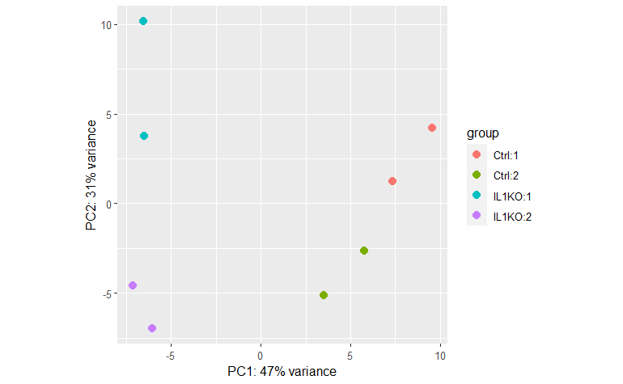

```r
# Filter low expressed genes: At least 1 cpm in at least 4 samples
idx <- which(rowSums(cpm(GSE165810.RawCounts[,-1]) >= 1) >= 4)

GSE165810.FilterCounts <- GSE165810.RawCounts[idx,]
rownames(GSE165810.FilterCounts) <- GSE165810.FilterCounts$Geneid
GSE165810.FilterCounts$Geneid <- NULL
GSE165810.coldata <- data.frame(Sample=colnames(GSE165810.FilterCounts),
                      Condition=factor(c("IL1KO","IL1KO","Ctrl","Ctrl","Ctrl","Ctrl","IL1KO","IL1KO")),
                      Batch=factor(rep(c(1,2),each=4))
)
rownames(GSE165810.coldata) <- GSE165810.coldata$Sample

GSE165810.dds <- DESeqDataSetFromMatrix(countData = GSE165810.FilterCounts,
                              colData = GSE165810.coldata,
                              design= ~ Batch + Condition)

GSE165810.dds$Condition <- relevel(GSE165810.dds$Condition, ref = "Ctrl")

GSE165810.dds <- DESeq(GSE165810.dds)

GSE165810.vsd <- vst(GSE165810.dds, blind=FALSE)

plotPCA(GSE165810.vsd,intgroup=c("Condition", "Batch"))
```

```r
GSE165810.res <- results(GSE165810.dds,alpha = 0.05)
GSE165810.res <- GSE165810.res[order(GSE165810.res$pvalue),]


summary(GSE165810.res)
```

```
out of 12978 with nonzero total read count
adjusted p-value < 0.05
LFC > 0 (up)       : 740, 5.7%
LFC < 0 (down)     : 735, 5.7%
outliers [1]       : 0, 0%
low counts [2]     : 0, 0%
(mean count < 18)
[1] see 'cooksCutoff' argument of ?results
[2] see 'independentFiltering' argument of ?results
```

```r
GSE165810.res <- as.data.frame(GSE165810.res) %>% mutate(padj2 = p.adjust(pvalue, method = "fdr"))

GSE165810.res %>% mutate(external_gene_name = rownames(GSE165810.res)) %>% as.data.frame() %>% write.xlsx(file = file.path(outputPath,"GSE165810.res.xlsx"),overwrite = T)
```

```r
objects <- c(objects,"GSE165810")

GSE165810 <- as.data.frame(GSE165810.res)
GSE165810$external_gene_name <- rownames(GSE165810)
GSE165810$padj2 <- GSE165810$padj

allSig <- data.frame(external_gene_name=unique(sort(c(
                      GSE165810 %>% filter(padj < 0.05) %>% .$external_gene_name,
                      LT_Il1rnKO %>% filter(padj < 0.05) %>% .$external_gene_name,
                      ST_Il1rnKO %>% filter(padj < 0.05) %>% .$external_gene_name,
                      MPP_Il1rnKO %>% filter(padj < 0.05) %>% .$external_gene_name))))

for (i in 1:length(objects)) {
  allSig <- allSig %>% left_join(get(objects[i]) %>% filter(padj < 0.05) %>% dplyr::select(external_gene_name,log2FoldChange),by = c("external_gene_name")) %>%
  rename(!!objects[i]:=log2FoldChange)
}

allSig$isTarget <- F
allSig[allSig$external_gene_name %in% nfkbGeneNames,"isTarget"] <- T
allSig %>% write.xlsx(file = file.path(outputPath,"GSE165810.AllSig.xlsx"),overwrite=T)
```

## 12.1 Overlaps

Total genes in common: 12638

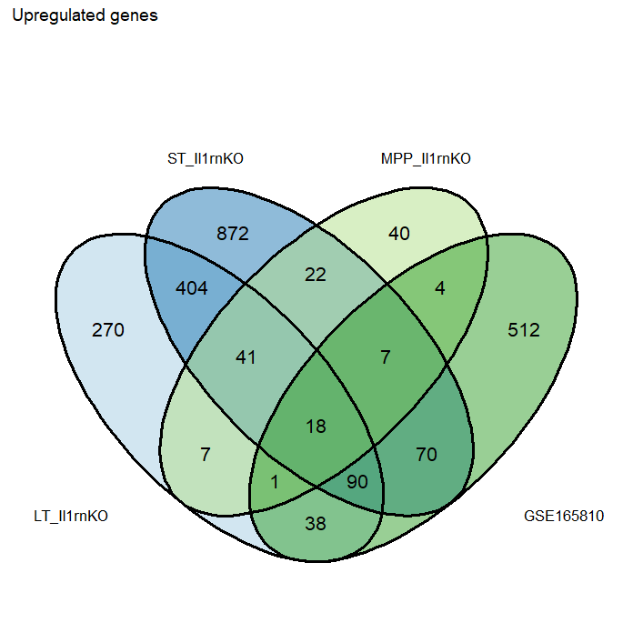

```r
deList <- list(
  LT_Il1rnKO = LT_Il1rnKO %>% filter(padj < 0.05 & log2FoldChange > 0) %>% .$external_gene_name,
  ST_Il1rnKO = ST_Il1rnKO %>% filter(padj < 0.05 & log2FoldChange > 0) %>% .$external_gene_name,
  MPP_Il1rnKO = MPP_Il1rnKO %>% filter(padj < 0.05 & log2FoldChange > 0) %>% .$external_gene_name,
  GSE165810 = GSE165810 %>% filter(padj < 0.05 & log2FoldChange > 0) %>% .$external_gene_name
)

p <- ggvenn(deList, names(deList),
             show_percentage = F,
             fill_color = color.list,
             set_name_size = 4,
             text_size = 5) +
  ggtitle("Upregulated genes")

print(p)
```

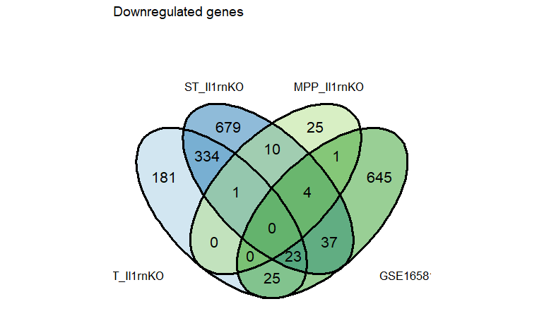

```r
deList <- list(
  LT_Il1rnKO = LT_Il1rnKO %>% filter(padj < 0.05 & log2FoldChange < 0) %>% .$external_gene_name,
  ST_Il1rnKO = ST_Il1rnKO %>% filter(padj < 0.05 & log2FoldChange < 0) %>% .$external_gene_name,
  MPP_Il1rnKO = MPP_Il1rnKO %>% filter(padj < 0.05 & log2FoldChange < 0) %>% .$external_gene_name,
  GSE165810 = GSE165810 %>% filter(padj < 0.05 & log2FoldChange < 0) %>% .$external_gene_name
)

p <- ggvenn(deList, names(deList),
             show_percentage = F,
             fill_color = color.list,
             set_name_size = 4,
             text_size = 5) +
  ggtitle("Downregulated genes")

print(p)
```

# 13 GSE166629 Contrast

```r
GSE166629.RawCounts <- read.delim(file = file.path(dataPath,"GSE166629.RawCounts.txt"),header = T,sep = "\t")
dim(GSE166629.RawCounts)
```

```
[1] 41414    13
```

```r
head(GSE166629.RawCounts)[,1:5]
```

|  | Geneid | WT_PBS_YFP_POS_rep1 | WT_PBS_YFP_POS_rep2 | WT_PBS_YFP_POS_rep3 | WT_PBS_YFP_NEG_rep1 |
| --- | --- | --- | --- | --- | --- |
| 1 | 0610005C13Rik | 10 | 4 | 17 | 28 |
| 2 | 0610006L08Rik | 0 | 0 | 0 | 0 |
| 3 | 0610007P14Rik | 615 | 600 | 701 | 459 |
| 4 | 0610009B22Rik | 248 | 215 | 177 | 138 |
| 5 | 0610009E02Rik | 21 | 7 | 0 | 23 |
| 6 | 0610009L18Rik | 71 | 32 | 39 | 21 |

```r
colnames(GSE166629.RawCounts)
```

```
 [1] "Geneid"              "WT_PBS_YFP_POS_rep1"
 [3] "WT_PBS_YFP_POS_rep2" "WT_PBS_YFP_POS_rep3"
 [5] "WT_PBS_YFP_NEG_rep1" "WT_PBS_YFP_NEG_rep2"
 [7] "WT_PBS_YFP_NEG_rep3" "WT_IL1_YFP_POS_rep1"
 [9] "WT_IL1_YFP_POS_rep2" "WT_IL1_YFP_POS_rep3"
[11] "WT_IL1_YFP_NEG_rep1" "WT_IL1_YFP_NEG_rep2"
[13] "WT_IL1_YFP_NEG_rep3"
```

```r
rownames(GSE166629.RawCounts) <- GSE166629.RawCounts$Geneid
GSE166629.RawCounts$Geneid <- NULL
GSE166629.RawCounts <- as.matrix(GSE166629.RawCounts)

sampleMetadataGSE166629 <- read.delim(file.path(dataPath,"GSE166629_SampleMetadata.txt"),sep = "\t")
sampleMetadataGSE166629 <- as.data.frame(t(sampleMetadataGSE166629))
colnames(sampleMetadataGSE166629) <- sampleMetadataGSE166629[1,]
sampleMetadataGSE166629 <- sampleMetadataGSE166629[-1,]
rownames(sampleMetadataGSE166629) <- sub("\\.","",rownames(sampleMetadataGSE166629))
sampleMetadataGSE166629$SampleName <- rownames(sampleMetadataGSE166629)
rownames(sampleMetadataGSE166629) <- sampleMetadataGSE166629$Sample_description
GSE166629.coldata <- sampleMetadataGSE166629 %>% rename("Condition"=treatment,"Group"=yfp)
rownames(GSE166629.coldata) <- GSE166629.coldata$SampleName

GSE166629.coldata <- GSE166629.coldata %>% filter(mouse_genotype == "WT")

GSE166629.RawCounts <- GSE166629.RawCounts[,rownames(GSE166629.coldata)]
```

## 13.1 YFP_POS

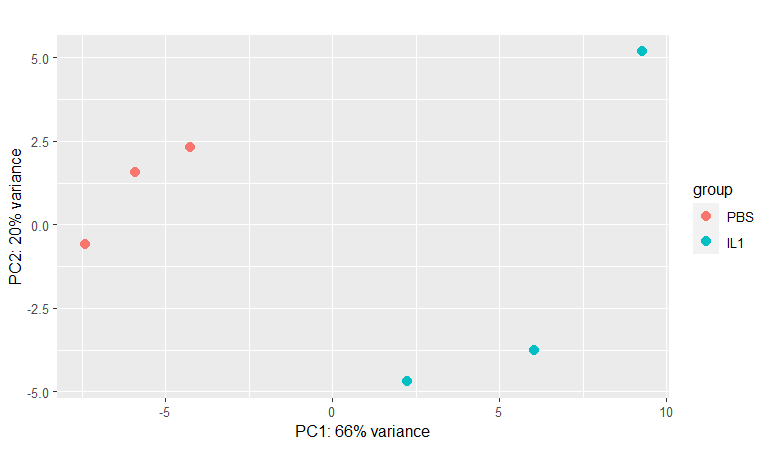

```r
YFP_POS_Group.coldata <- GSE166629.coldata %>% filter(Group == "YFP_POS" & mouse_genotype == "WT")

YFP_POS_Group.RawCounts <- GSE166629.RawCounts[,rownames(YFP_POS_Group.coldata)]

# Filter low expressed genes: At least 1 cpm in at least 3 samples
idx <- which(rowSums(cpm(YFP_POS_Group.RawCounts) >= 1) >= 3)

YFP_POS_Group.FilterCounts <- YFP_POS_Group.RawCounts[idx,]

YFP_POS_Group.dds <- DESeqDataSetFromMatrix(countData = YFP_POS_Group.FilterCounts,
                              colData = YFP_POS_Group.coldata,
                              design= ~ Condition)

YFP_POS_Group.dds$Condition <- relevel(YFP_POS_Group.dds$Condition, ref = "PBS")

YFP_POS_Group.dds <- DESeq(YFP_POS_Group.dds)

YFP_POS_Group.vsd <- vst(YFP_POS_Group.dds, blind=FALSE)

plotPCA(YFP_POS_Group.vsd,intgroup=c("Condition"))
```

```r
YFP_POS_Group.res <- results(YFP_POS_Group.dds,alpha = 0.05)
YFP_POS_Group.res <- YFP_POS_Group.res[order(YFP_POS_Group.res$pvalue),]

summary(YFP_POS_Group.res)
```

```
out of 13879 with nonzero total read count
adjusted p-value < 0.05
LFC > 0 (up)       : 260, 1.9%
LFC < 0 (down)     : 321, 2.3%
outliers [1]       : 3, 0.022%
low counts [2]     : 0, 0%
(mean count < 16)
[1] see 'cooksCutoff' argument of ?results
[2] see 'independentFiltering' argument of ?results
```

```r
YFP_POS_Group.res <- as.data.frame(YFP_POS_Group.res) %>% mutate(padj2 = p.adjust(pvalue, method = "fdr"))

YFP_POS_Group.res %>% mutate(external_gene_name = rownames(YFP_POS_Group.res)) %>%  as.data.frame() %>% write.xlsx(file = file.path(outputPath,"YFP_POS_Group.res.xlsx"),overwrite = T)
```

```r
objects <- c("LT_Il1rnKO","ST_Il1rnKO","MPP_Il1rnKO","YFP_POS_Group")

YFP_POS_Group <- as.data.frame(YFP_POS_Group.res)
YFP_POS_Group$external_gene_name <- rownames(YFP_POS_Group)
YFP_POS_Group$padj2 <- YFP_POS_Group$padj


allSig <- data.frame(external_gene_name=unique(sort(c(
                      YFP_POS_Group %>% filter(padj < 0.05) %>% .$external_gene_name,
                      LT_Il1rnKO %>% filter(padj < 0.05) %>% .$external_gene_name,
                      ST_Il1rnKO %>% filter(padj < 0.05) %>% .$external_gene_name,
                      MPP_Il1rnKO %>% filter(padj < 0.05) %>% .$external_gene_name))))

for (i in 1:length(objects)) {
  allSig <- allSig %>% left_join(get(objects[i]) %>% filter(padj < 0.05) %>% dplyr::select(external_gene_name,log2FoldChange),by = c("external_gene_name")) %>%
  rename(!!objects[i]:=log2FoldChange)
}

allSig$isTarget <- F
allSig[allSig$external_gene_name %in% nfkbGeneNames,"isTarget"] <- T
allSig %>% write.xlsx(file = file.path(outputPath,"YFP_POS_Group.AllSig.xlsx"),overwrite=T)
```

### 13.1.1 Overlaps

Total genes in common: 12602

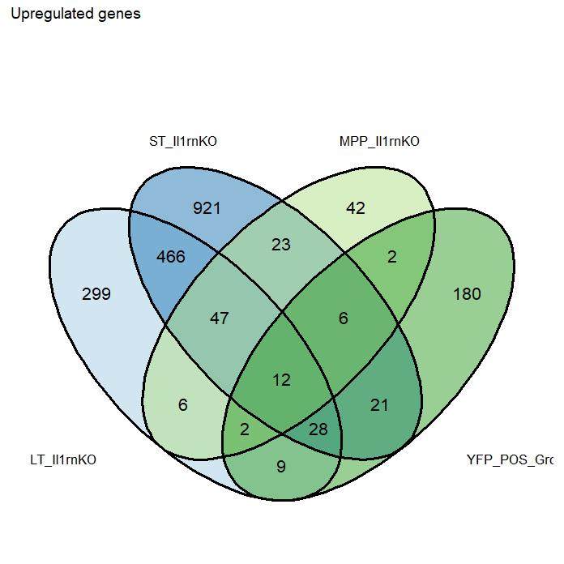

```r
### Upregulated
deList <- list(
  LT_Il1rnKO = LT_Il1rnKO %>% filter(padj < 0.05 & log2FoldChange > 0) %>% .$external_gene_name,
  ST_Il1rnKO = ST_Il1rnKO %>% filter(padj < 0.05 & log2FoldChange > 0) %>% .$external_gene_name,
  MPP_Il1rnKO = MPP_Il1rnKO %>% filter(padj < 0.05 & log2FoldChange > 0) %>% .$external_gene_name,
  YFP_POS_Group = YFP_POS_Group %>% filter(padj < 0.05 & log2FoldChange > 0) %>% .$external_gene_name
)

p <- ggvenn(deList, names(deList),
             show_percentage = F,
             fill_color = color.list,
             set_name_size = 4,
             text_size = 5) +
  ggtitle("Upregulated genes")

print(p)
```

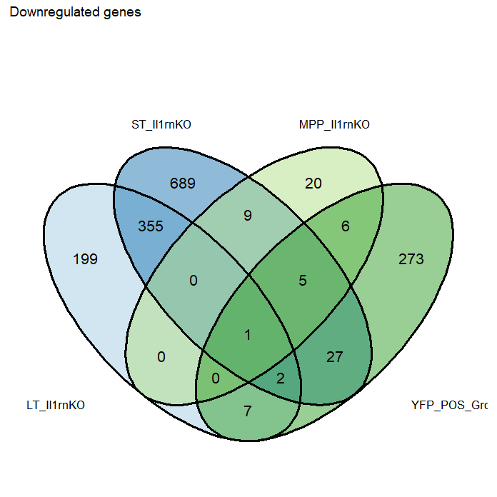

```r
deList <- list(
  LT_Il1rnKO = LT_Il1rnKO %>% filter(padj < 0.05 & log2FoldChange < 0) %>% .$external_gene_name,
  ST_Il1rnKO = ST_Il1rnKO %>% filter(padj < 0.05 & log2FoldChange < 0) %>% .$external_gene_name,
  MPP_Il1rnKO = MPP_Il1rnKO %>% filter(padj < 0.05 & log2FoldChange < 0) %>% .$external_gene_name,
  YFP_POS_Group = YFP_POS_Group %>% filter(padj < 0.05 & log2FoldChange < 0) %>% .$external_gene_name
)

### Downregulated
p <- ggvenn(deList, names(deList),
             show_percentage = F,
             fill_color = color.list,
             set_name_size = 4,
             text_size = 5) +
  ggtitle("Downregulated genes")

print(p)
```

## 13.2 YFP_NEG

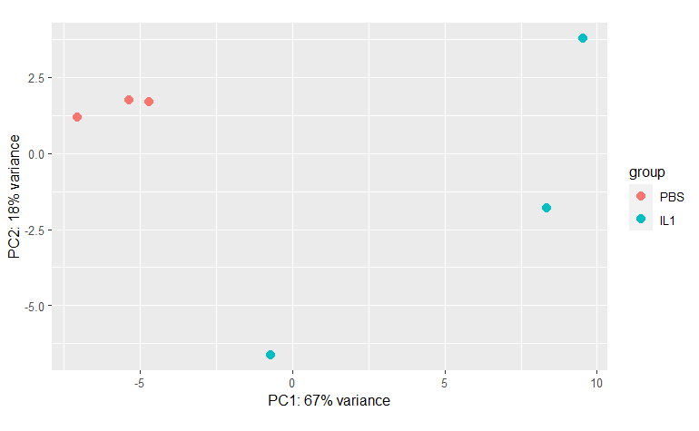

```r
YFP_NEG_Group.coldata <- GSE166629.coldata %>% filter(Group == "YFP_NEG" & mouse_genotype == "WT")

YFP_NEG_Group.RawCounts <- GSE166629.RawCounts[,rownames(YFP_NEG_Group.coldata)]

# Filter low expressed genes: At least 1 cpm in at least 3 samples
idx <- which(rowSums(cpm(YFP_NEG_Group.RawCounts) >= 1) >= 3)

YFP_NEG_Group.FilterCounts <- YFP_NEG_Group.RawCounts[idx,]

YFP_NEG_Group.dds <- DESeqDataSetFromMatrix(countData = YFP_NEG_Group.FilterCounts,
                              colData = YFP_NEG_Group.coldata,
                              design= ~ Condition)

YFP_NEG_Group.dds$Condition <- relevel(YFP_NEG_Group.dds$Condition, ref = "PBS")

YFP_NEG_Group.dds <- DESeq(YFP_NEG_Group.dds)

YFP_NEG_Group.vsd <- vst(YFP_NEG_Group.dds, blind=FALSE)

plotPCA(YFP_NEG_Group.vsd,intgroup=c("Condition"))
```

```r
YFP_NEG_Group.res <- results(YFP_NEG_Group.dds,alpha = 0.05)
YFP_NEG_Group.res <- YFP_NEG_Group.res[order(YFP_NEG_Group.res$pvalue),]


summary(YFP_NEG_Group.res)
```

```
out of 13899 with nonzero total read count
adjusted p-value < 0.05
LFC > 0 (up)       : 197, 1.4%
LFC < 0 (down)     : 232, 1.7%
outliers [1]       : 8, 0.058%
low counts [2]     : 0, 0%
(mean count < 15)
[1] see 'cooksCutoff' argument of ?results
[2] see 'independentFiltering' argument of ?results
```

```r
YFP_NEG_Group.res <- as.data.frame(YFP_NEG_Group.res) %>% mutate(padj2 = p.adjust(pvalue, method = "fdr"))

YFP_NEG_Group.res %>% mutate(external_gene_name = rownames(YFP_NEG_Group.res)) %>% as.data.frame() %>% write.xlsx(file = file.path(outputPath,"YFP_NEG_Group.res.xlsx"),overwrite = T)
```

```r
objects <- c("LT_Il1rnKO","ST_Il1rnKO","MPP_Il1rnKO","YFP_NEG_Group")

YFP_NEG_Group <- as.data.frame(YFP_NEG_Group.res)
YFP_NEG_Group$external_gene_name <- rownames(YFP_NEG_Group)
YFP_NEG_Group$padj2 <- YFP_NEG_Group$padj


allSig <- data.frame(external_gene_name=unique(sort(c(
                      YFP_NEG_Group %>% filter(padj < 0.05) %>% .$external_gene_name,
                      LT_Il1rnKO %>% filter(padj < 0.05) %>% .$external_gene_name,
                      ST_Il1rnKO %>% filter(padj < 0.05) %>% .$external_gene_name,
                      MPP_Il1rnKO %>% filter(padj < 0.05) %>% .$external_gene_name))))

for (i in 1:length(objects)) {
  allSig <- allSig %>% left_join(get(objects[i]) %>% filter(padj < 0.05) %>% dplyr::select(external_gene_name,log2FoldChange),by = c("external_gene_name")) %>%
  rename(!!objects[i]:=log2FoldChange)
}

allSig$isTarget <- F
allSig[allSig$external_gene_name %in% nfkbGeneNames,"isTarget"] <- T
allSig %>% write.xlsx(file = file.path(outputPath,"YFP_NEG_Group.AllSig.xlsx"),overwrite=T)
```

### 13.2.1 Overlaps

Total genes in common: 12653

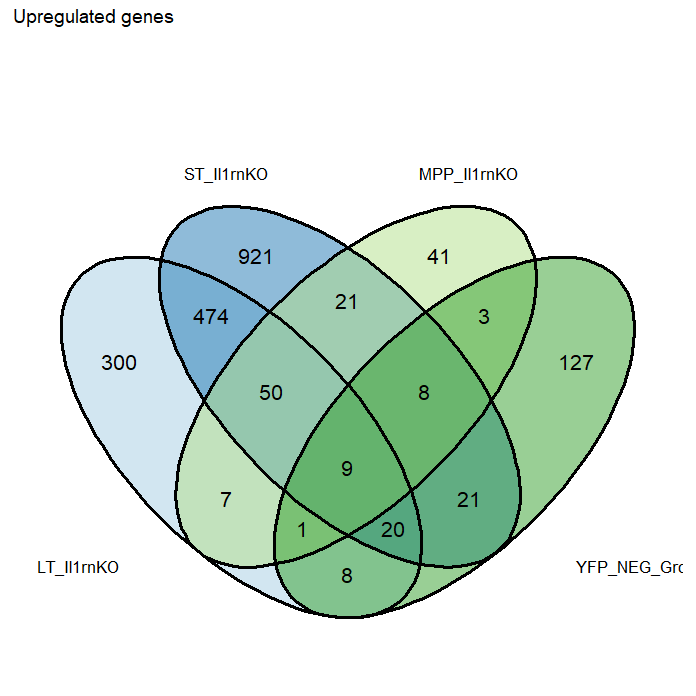

```r
deList <- list(
  LT_Il1rnKO = LT_Il1rnKO %>% filter(padj < 0.05 & log2FoldChange > 0) %>% .$external_gene_name,
  ST_Il1rnKO = ST_Il1rnKO %>% filter(padj < 0.05 & log2FoldChange > 0) %>% .$external_gene_name,
  MPP_Il1rnKO = MPP_Il1rnKO %>% filter(padj < 0.05 & log2FoldChange > 0) %>% .$external_gene_name,
  YFP_NEG_Group = YFP_NEG_Group %>% filter(padj < 0.05 & log2FoldChange > 0) %>% .$external_gene_name
)

p <- ggvenn(deList, names(deList),
             show_percentage = F,
             fill_color = color.list,
             set_name_size = 4,
             text_size = 5) +
  ggtitle("Upregulated genes")

print(p)
```

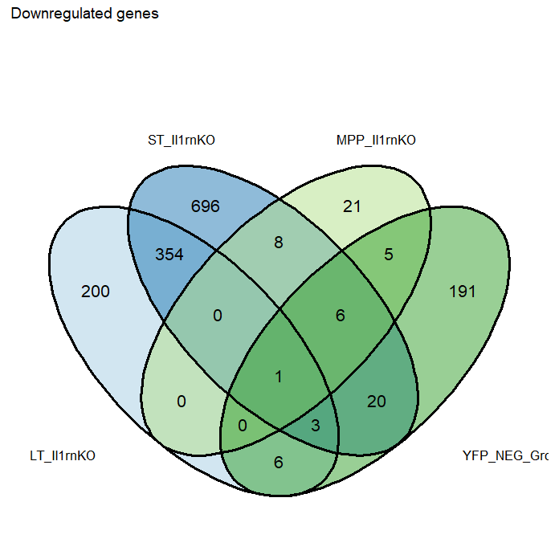

```r
deList <- list(
  LT_Il1rnKO = LT_Il1rnKO %>% filter(padj < 0.05 & log2FoldChange < 0) %>% .$external_gene_name,
  ST_Il1rnKO = ST_Il1rnKO %>% filter(padj < 0.05 & log2FoldChange < 0) %>% .$external_gene_name,
  MPP_Il1rnKO = MPP_Il1rnKO %>% filter(padj < 0.05 & log2FoldChange < 0) %>% .$external_gene_name,
  YFP_NEG_Group = YFP_NEG_Group %>% filter(padj < 0.05 & log2FoldChange < 0) %>% .$external_gene_name
)

p <- ggvenn(deList, names(deList),
             show_percentage = F,
             fill_color = color.list,
             set_name_size = 4,
             text_size = 5) +
  ggtitle("Downregulated genes")

print(p)
```